# DESeq2 Pkd2-KO Analyses

Lizzy Ramsey

3/30/2022

### Purpose

This markdown uses STAR salmon counts from nf-core for RNAseq alignment. All data from publicly available mouse kidney RNAseq data comparing PKD2-KO and WT.  
**P70**: AKA 39/GSE149739/precystic/p70, induced-KO model, samples collected at p70 when tubules were dilated with no overt cyst formation. Total n = 6 samples, 3 Pkd2fl/fl;Pax8rtTA;TetO-Cre and 3 WT  
Dataset: GSE149739  
Processed data filepath: /data/project/lasseigne_lab/Lizzy/PKD_drugrepurposing_220324/

**P21**: AKA 56/GSE69556/cystic/p21, kidney-specific KO model, samples collected at p21 from full-blown cystic kidneys. Total n = 7, 3 Pkhd1-Cre; Pkd2fl/fl and 4 WT  
Dataset: GSE69556  
Processed data filepath: /data/project/lasseigne_lab/Lizzy/PKD_drugrepurposing_220324/

**P28**: AKA 19/GSE134719/cystic/p28, kidney-specific KO model, samples collected at p28 from full-blown cystic kidneys. Total n = 23, 11 Pkhd1-Cre; Pkd2fl/fl and 12 WT  
Dataset: GSE134719  
Processed data filepath: /data/project/lasseigne_lab/Lizzy/PKD_drugrepurposing_220324/

#### Load in libraries

```r
library(DESeq2)
library(stringr)
library(apeglm)
library(pheatmap)
library(dplyr)
library(ggrepel)
library(signatureSearch)
library(ExperimentHub); library(rhdf5)
library(biomaRt)
library(viridis)
library(here)
library(EnhancedVolcano)
source(here("code", "functions.R"))
```

### DEA p70 precystic GSE149739

#### Read in data

Filepath to counts data: /data/project/lasseigne_lab/Lizzy/PKD_drugrepurposing_220324/  
Metadata: https://www.ncbi.nlm.nih.gov/geo/query/acc.cgi?acc=GSE149739

```r
cts_39 <- readRDS(here("data", "GSE149739_salmonmerged_gene_counts.rds"))
meta_39 <- read.csv(here("data", "GSE149739_metadata.txt"), row.names = 1)
```

Remove IFT88

```r
ift88 <- grep("Ift88", meta_39$Genotype, ignore.case = TRUE, value = TRUE)
nonift88 <- meta_39$Genotype[!(meta_39$Genotype %in% ift88)]
meta_39 <- dplyr::filter(meta_39, Genotype %in% nonift88)
```

#### DDS

```r
cts_39 <- cts_39@assays@data@listData[["counts"]]
dds_39 <- salmon2dds(cts_39, meta_39)
```

```
## [1] "Checking order of count column names to metadata rownames... If false, fix and rerun!"
## [1] TRUE TRUE TRUE TRUE TRUE TRUE
```

#### Run DESeq2

```r
#relevel to make wildtype the reference instead of first alphabetical factor
dds_39$Genotype <- relevel(dds_39$Genotype, ref = "Wildtype")
#run DESeq: estimates size factors, estimates dispersion, fits negative binomial GLM's and performs Wald stats
dds_39 <- DESeq(dds_39)
```

#### Results

```r
#extract results table with log2 fold changes, p values and adjusted p values for desired coefficients
#alpha 0.05 cutoff
#res_nf <- results(dds_39, alpha = 0.05, contrast = c("Genotype", "Pkd2flflPax8rtTATetOcre", "Wildtype"))
res_nf <- lfcShrink(dds_39, coef = c("Genotype_Pkd2flflPax8rtTATetOcre_vs_Wildtype"), type="apeglm")
```

```
## using 'apeglm' for LFC shrinkage. If used in published research, please cite:
##     Zhu, A., Ibrahim, J.G., Love, M.I. (2018) Heavy-tailed prior distributions for
##     sequence count data: removing the noise and preserving large differences.
##     Bioinformatics. https://doi.org/10.1093/bioinformatics/bty895
```

```r
res_nf
```

```
## log2 fold change (MAP): Genotype Pkd2flflPax8rtTATetOcre vs Wildtype
## Wald test p-value: Genotype Pkd2flflPax8rtTATetOcre vs Wildtype
## DataFrame with 55471 rows and 5 columns
##                     baseMean log2FoldChange     lfcSE    pvalue      padj
##                    <numeric>      <numeric> <numeric> <numeric> <numeric>
## ENSMUSG00000000001 4784.2998     0.04867316 0.0792269  0.453205  0.799985
## ENSMUSG00000000003    0.0000             NA        NA        NA        NA
## ENSMUSG00000000028   99.1294     0.10058030 0.1687573  0.116513  0.445438
## ENSMUSG00000000031   10.1791    -0.00156955 0.1376507  0.932265  0.985070
## ENSMUSG00000000037   23.4236     0.03422403 0.1403753  0.326265  0.705814
## ...                      ...            ...       ...       ...       ...
## ENSMUSG00000118636  0.000000             NA        NA        NA        NA
## ENSMUSG00000118637 24.746320     0.05743852  0.151454  0.114254  0.441129
## ENSMUSG00000118638  0.000000             NA        NA        NA        NA
## ENSMUSG00000118639  0.000000             NA        NA        NA        NA
## ENSMUSG00000118640  0.649666     0.00343515  0.139044  0.489498        NA
```

DESeq2 results

```r
dsq2_39 <- as.data.frame(res_nf)
```

Save full deseq results

```r
write.csv(dsq2_39, file = here("res", "deseq2_outputs", "deseq2_fullres_39.csv"))
saveRDS(dsq2_39, file = here("res", "deseq2_outputs", "deseq2_fullres_39.rds"))
```

#### LFC cutoffs

```r
musdegs_39_UP <- uplfc(dsq2_39, lfcutoff = 1.1)
musdegs_39_DOWN <- downlfc(dsq2_39, lfcutoff = -1.1)
```

Total genes above threshold before mapping from mouse ensembl to human symbol/entrez

```r
dim(musdegs_39_UP) #159 at lfc > 1.3 , 194 at lfc > 1.1
```

```
## [1] 194   6
```

```r
dim(musdegs_39_DOWN) #43 at lfc < -1.3  , 63 at lfc <   63
```

```
## [1] 63  6
```

```r
write.csv(musdegs_39_UP, file = here("res", "deseq2_outputs", "deseq2_upgenes_res_39.csv"))
write.csv(musdegs_39_DOWN, file = here("res", "deseq2_outputs", "deseq2_downgenes_res_39.csv"))
```

Regularized log transformation  
rlog() is better to use for these datasets – better for high count variance by sample (in this case, one sample has over 2x the reads compared to the others in one data set) and for smaller datasets “if you have many samples (e.g. 100s), the rlog function might take too long, and so the vst function will be a faster choice. The rlog and VST have similar properties, but the rlog requires fitting a shrinkage term for each sample and each gene which takes time. See the DESeq2 paper for more discussion on the differences (Love, Huber, and Anders 2014).”

```r
#vsd_nf <- vst(dds_39, blind = FALSE) #if blind, could minimize large count differences due to anticipated experimental variation
rld_nf <- rlog(dds_39, blind = FALSE)
```

#### Visualizations

PCA

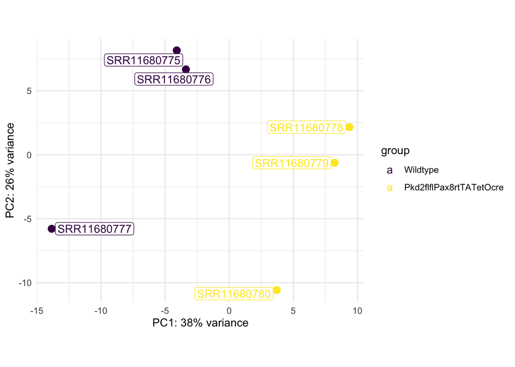

```r
plotPCA(rld_nf, intgroup=c("Genotype")) + geom_label_repel(aes(label = rld_nf@colData@rownames), box.padding   = 0.15, label.padding = 0.15, point.padding = 0.3, segment.color = 'grey50') + scale_colour_viridis_d() + theme(axis.title.x = element_text(size = 20)) + theme_minimal()
```

#### Mouse to Human Ortholog Mapping

Map to human entrez and filter by LINCS genes

```r
hom_degs_UP <- lincsGenes(musdegs_39_UP, "up")

hom_degs_DOWN <-  lincsGenes(musdegs_39_DOWN, "down")
#should be 100 or less
length(unique(hom_degs_UP$entrezgene_id)) #99
```

```
## [1] 99
```

```r
length(unique(hom_degs_DOWN$entrezgene_id)) #31
```

```
## [1] 31
```

```r
write.csv(hom_degs_UP, file = here("res", "deseq2_outputs", "p70_signature_UP.csv"))
write.csv(hom_degs_DOWN, file = here("res", "deseq2_outputs", "p70_signature_DOWN.csv"))
```

#### Heatmap plotting

Map measured mouse ensembl genes to mouse MGI symbol genes and then filter for coding genes (remove pseudogenes, ribosomal, and predicted)

```r
#retrieve counts data and ENMUSG #
cts_df <- as.data.frame(assays((rld_nf)))
#gene_id into a column
cts_df <- tibble:::rownames_to_column(cts_df, var = "ensembl_gene_id")
#biomart to pull gene symbls and descriptions
mouse <- useEnsembl("ensembl", dataset = "mmusculus_gene_ensembl", mirror = "useast")
gene_desc <- getBM(filters = "ensembl_gene_id", attributes = c("ensembl_gene_id","entrezgene_id", "mgi_symbol", "description"), values = cts_df$ensembl_gene_id, mart = mouse)
ps <- grep("pseudogene", gene_desc$description, value = TRUE)
rp <- grep("ribosom", gene_desc$description, value = TRUE)
pred <- grep("predicted", gene_desc$description, value = TRUE)
coding_genes <- dplyr::filter(gene_desc, !description %in% c(ps) & !description %in% c(rp) & !description %in% c(pred))
```

converting gene IDs for normalized (rlog) gene counts

```r
#Merge gene symbols into counts and gene ID
conv_cts_all <- merge(cts_df, coding_genes, by = "ensembl_gene_id")
#Filter out repeating data
conv_cts_all <- dplyr::distinct(conv_cts_all, mgi_symbol, .keep_all = TRUE)
#Convert back to rownames but with gene symbols
conv_cts <- tibble:::column_to_rownames(conv_cts_all, "mgi_symbol")
conv_cts <- subset(conv_cts, select = c("SRR11680775", "SRR11680776", "SRR11680777", "SRR11680778", "SRR11680779", "SRR11680780"))
#Remove extra columns
conv_cts <- conv_cts[,!(colnames(conv_cts) %in% c("ensembl_gene_id", "group", "group_name", "entrezgene_id", "description"))]
colnames(conv_cts) <- c("WT", "WT", "WT", "Pkd2KO", "Pkd2KO", "Pkd2KO")
```

greatest LFC, wrangling

```r
genes <-  tibble:::rownames_to_column(dsq2_39, var = "ensembl_gene_id")
#Merge gene symbols into counts and gene ID
genes <- merge(genes, coding_genes, by = "ensembl_gene_id")
#Filter out repeating data
genes <- dplyr::distinct(genes, mgi_symbol, .keep_all = TRUE)
#Convert back to rownames but with gene symbols
genes <-  tibble:::column_to_rownames(genes, "mgi_symbol")
#top 20
top20lfc <- dplyr::slice_max(genes, abs(log2FoldChange), n = 20)
```

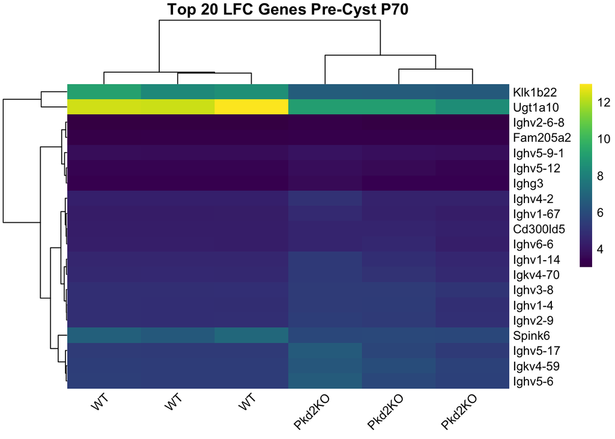

```r
heatmap_p70 <- pheatmap::pheatmap(conv_cts[rownames(top20lfc), ], cluster_rows = TRUE, cluster_cols = TRUE, show_rownames = TRUE, color = viridis(n= 10000, alpha = 1, begin = 0, end = 1, option = "viridis"), border_color = "NA", main = "Top 20 LFC Genes Pre-Cyst P70", angle_col = "45")
```

```r
write.csv(genes, file = here("res/deseq2_outputs", "deseq2_p70_fullannotatedres.csv"))
ggsave(heatmap_p70, filename = here("res", "fea", "heatmap_p70.pdf"), height = 7, width = 14)
```

gene signature

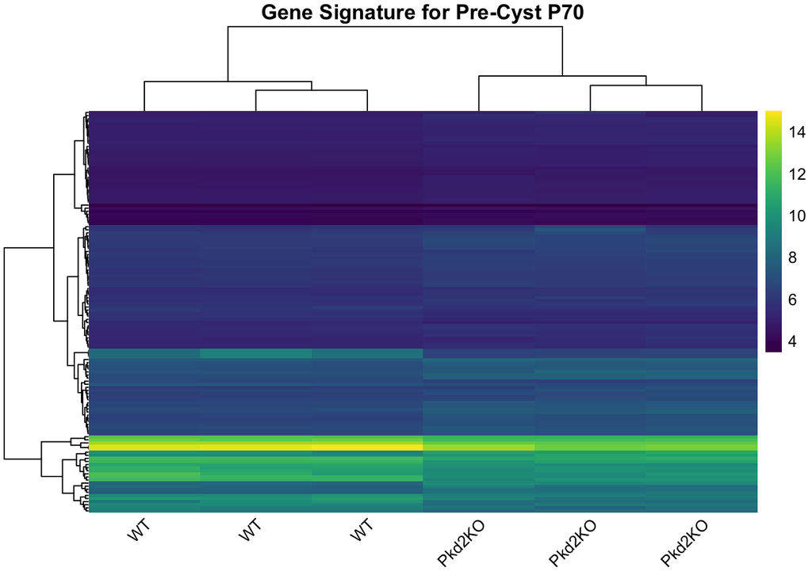

```r
sig_39 <- rbind(hom_degs_UP, hom_degs_DOWN)
sig_39 <- merge(sig_39, conv_cts_all, by.x = "Mouse.gene.stable.ID", by.y = "ensembl_gene_id")
#Filter out repeating data
sig_39 <- dplyr::distinct(sig_39, hgnc_symbol, .keep_all = TRUE)
sig_39_cts <- tibble::column_to_rownames(sig_39, "hgnc_symbol")
sig_39_cts <- dplyr::select(sig_39_cts, starts_with("SRR"))
colnames(sig_39_cts) <- c("WT", "WT", "WT", "Pkd2KO", "Pkd2KO", "Pkd2KO")
heatmap_p70 <- pheatmap::pheatmap(sig_39_cts[row.names(sig_39_cts), ], cluster_rows = TRUE, cluster_cols = TRUE, show_rownames = FALSE, fontsize_row = 3, color = viridis(n= 10000, alpha = 1, begin = 0, end = 1, option = "viridis"), border_color = "NA", main = "Gene Signature for Pre-Cyst P70", angle_col = "45")
```

```r
#heatmap_p70 <- pheatmap(sig_39_cts, cluster_rows = TRUE, cluster_cols = TRUE, show_rownames = FALSE, color = viridis(n= 10000, alpha = 1, begin = 0, end = 1, option = "viridis"), border_color = "NA", main = "Gene Signature for Pre-Cyst P70", annotation_col = colnames(sig_39_cts))
```

```r
write.csv(sig_39, here("res/deseq2_outputs", "signature_annotation_p70.csv"))
ggsave(heatmap_p70, filename = here("res/deseq2_outputs", "heatmap_p70_signature.png"))
```

### DEA p21 cystic GSE69556

#### Read in data

**Filepath to fastq’s and metadata**: /data/project/lasseigne_lab/DATASET_dir/pkdDrugRepurposing/pkd2/GSE69556/SraRunTable.txt  
**Filepath to counts data**: /data/project/lasseigne_lab/Lizzy/PKD_drugrepurposing_220324/GSE69556_nfcore/results/star_salmon/salmon.merged.gene_counts.rds

```r
cts_56 <- readRDS(here("data", "GSE69556_salmonmerged_gene_counts.rds"))
cts_56 <- cts_56@assays@data@listData[["counts"]]
colnames(cts_56) <- str_sub(colnames(cts_56), 1, -2) #remove random period at the end of the sample names
meta_56 <- read.csv(here("data", "GSE69556_metadata.txt"), row.names = 1)
```

#### DDS

```r
dds_56 <- salmon2dds(cts_56, meta_56)
```

```
## [1] "Checking order of count column names to metadata rownames... If false, fix and rerun!"
## [1] TRUE TRUE TRUE TRUE TRUE TRUE TRUE
```

#### Run DESeq2

```r
#relevel to make wildtype the reference instead of first alphabetical factor
dds_56$Genotype <- relevel(dds_56$Genotype, ref = "wildtype")
#run DESeq: estimates size factors, estimates dispersion, fits negative binomial GLM's and performs Wald stats
dds_56 <- DESeq(dds_56) #can also look at setting replaceOutliers lower for dealing with outliers
```

#### Results

```r
#extract results table with log2 fold changes, p values and adjusted p values for desired coefficients
#res_56 <- results(dds_56, alpha = 0.05, contrast = c("Genotype", "Pkhd1CrePkd2FF", "wildtype"))
res_56 <- lfcShrink(dds_56, coef = c("Genotype_Pkhd1CrePkd2FF_vs_wildtype"), type="apeglm")
```

```
## using 'apeglm' for LFC shrinkage. If used in published research, please cite:
##     Zhu, A., Ibrahim, J.G., Love, M.I. (2018) Heavy-tailed prior distributions for
##     sequence count data: removing the noise and preserving large differences.
##     Bioinformatics. https://doi.org/10.1093/bioinformatics/bty895
```

```r
res_56
```

```
## log2 fold change (MAP): Genotype Pkhd1CrePkd2FF vs wildtype
## Wald test p-value: Genotype Pkhd1CrePkd2FF vs wildtype
## DataFrame with 55471 rows and 5 columns
##                     baseMean log2FoldChange     lfcSE    pvalue      padj
##                    <numeric>      <numeric> <numeric> <numeric> <numeric>
## ENSMUSG00000000001 4784.5960       0.130263  0.162492 0.3846184 0.6614682
## ENSMUSG00000000003    0.0000             NA        NA        NA        NA
## ENSMUSG00000000028  180.7045       0.675038  0.357784 0.0130402 0.0628258
## ENSMUSG00000000031  295.1528      -0.157440  0.351533 0.4650983 0.7307178
## ENSMUSG00000000037   45.6243       0.261910  0.348068 0.2622640 0.5343794
## ...                      ...            ...       ...       ...       ...
## ENSMUSG00000118636  0.000000             NA        NA        NA        NA
## ENSMUSG00000118637  0.353989      0.0113348  0.425495  0.805331        NA
## ENSMUSG00000118638  0.000000             NA        NA        NA        NA
## ENSMUSG00000118639  0.000000             NA        NA        NA        NA
## ENSMUSG00000118640  0.000000             NA        NA        NA        NA
```

DESeq2 results as df and by LFC threshold

```r
dsq2_56 <- as.data.frame(res_56)
```

```r
write.csv(dsq2_56, file = here("res/deseq2_outputs", "deseq2_fullres_56.csv"))
saveRDS(dsq2_56, file = here("res", "deseq2_outputs", "deseq2_fullres_56.rds"))
```

#### LFC cutoffs

```r
#NAs removed  p-adjusted value cutoff 0.05 and log2fc greater than 2.0 and less than -2.0
musdegs_56_UP <- uplfc(dsq2_56, 2.0)
musdegs_56_DOWN <- downlfc(dsq2_56, -2.0)
```

Total genes above threshold before mapping from mouse ensembl to human symbol/entrez

```r
dim(musdegs_56_UP) #364
```

```
## [1] 364   6
```

```r
dim(musdegs_56_DOWN) #57
```

```
## [1] 57  6
```

Map to human entrez and filter by LINCS genes

```r
hom_56_UP <- lincsGenes(musdegs_56_UP, "up")
hom_56_DOWN <-  lincsGenes(musdegs_56_DOWN, "down")
#should be 100 or less
length(unique(hom_56_UP$entrezgene_id)) #98
```

```
## [1] 98
```

```r
length(unique(hom_56_DOWN$entrezgene_id)) #28
```

```
## [1] 28
```

```r
write.csv(musdegs_56_UP, file = here("res", "deseq2_outputs", "deseq2_upgenes_res_56.csv"))
write.csv(musdegs_56_DOWN, file = here("res", "deseq2_outputs", "deseq2_downgenes_res_56.csv"))
write.csv(hom_56_UP, file = here("res", "deseq2_outputs", "p21_signature_UP.csv"))
write.csv(hom_56_DOWN, file = here("res", "deseq2_outputs", "p21_signature_DOWN.csv"))
```

Regularized log transformation  
rlog() is better to use for these datasets – better for high count variance by sample (in this case, one sample has over 2x the reads compared to the others in one data set) and for smaller datasets “if you have many samples (e.g. 100s), the rlog function might take too long, and so the vst function will be a faster choice. The rlog and VST have similar properties, but the rlog requires fitting a shrinkage term for each sample and each gene which takes time. See the DESeq2 paper for more discussion on the differences (Love, Huber, and Anders 2014).”

```r
rld_56 <- rlog(dds_56, blind = FALSE)
```

#### Visualizations

PCA

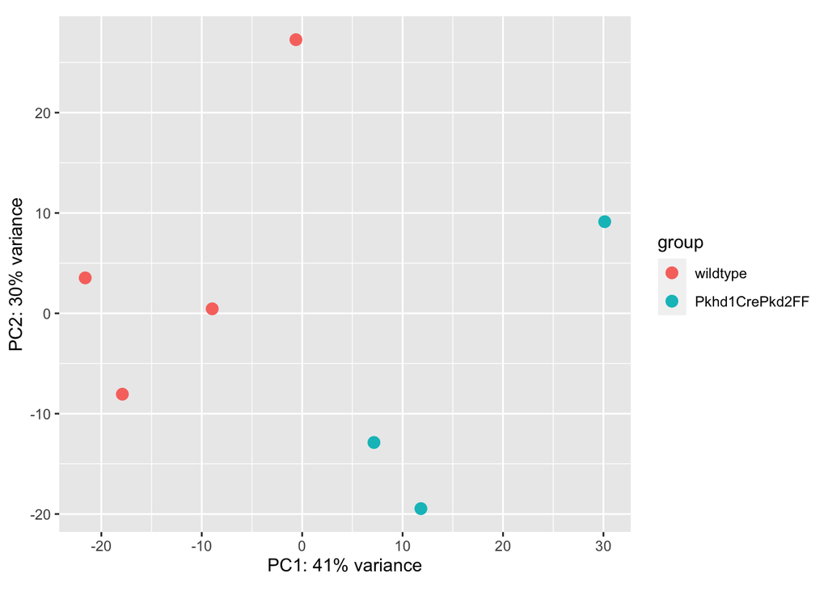

```r
#regularized log transformation
plotPCA(rld_56, intgroup=c("Genotype"))
```

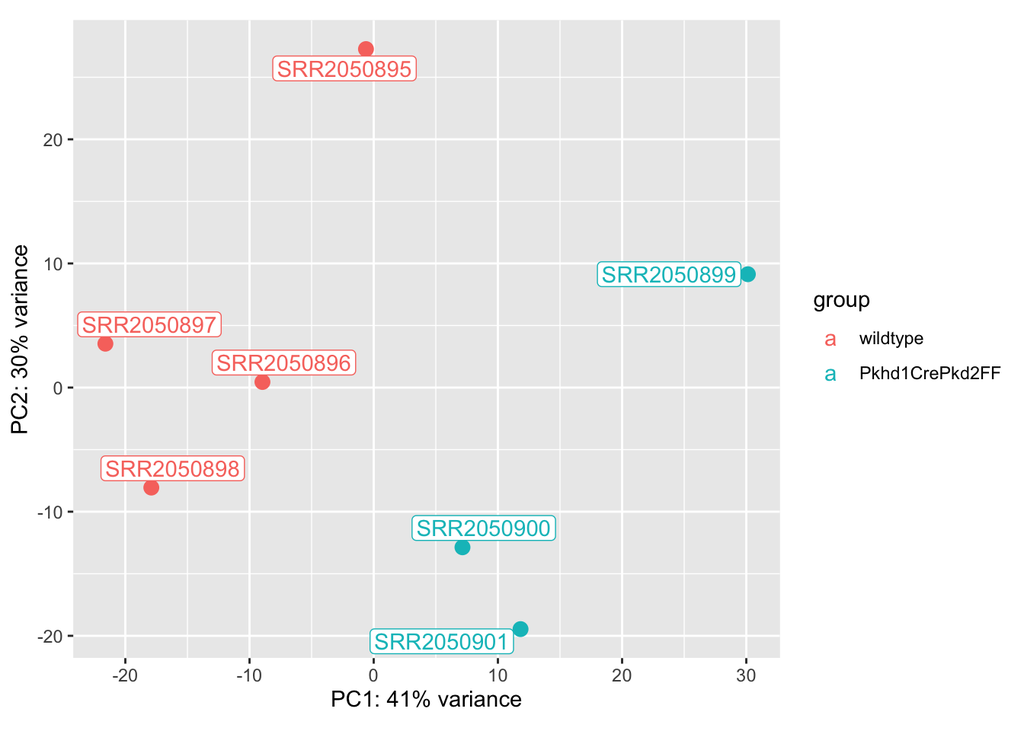

```r
#label samples
plotPCA(rld_56, intgroup=c("Genotype")) + geom_label_repel(aes(label = rld_56@colData@rownames), box.padding   = 0.15, label.padding = 0.15, point.padding = 0.3, segment.color = 'grey50')
```

#### Heatmap plotting

converting gene IDs for normalized (rlog) gene counts

```r
#retrieve counts data and ENMUSG #
cts_df_56 <- as.data.frame(assays((rld_56)))
#gene_id into a column
cts_df_56 <- tibble:::rownames_to_column(cts_df_56, var = "ensembl_gene_id")
#Merge gene symbols into counts and gene ID
conv_cts_56_all <- merge(cts_df_56, coding_genes, by = "ensembl_gene_id")
#Filter out repeating data
conv_cts_56_all <- dplyr::distinct(conv_cts_56_all, mgi_symbol, .keep_all = TRUE)
#Convert back to rownames but with gene symbols
conv_cts_56 <- tibble:::column_to_rownames(conv_cts_56_all, "mgi_symbol")
#Remove unnecessary data
conv_cts_56 <- conv_cts_56[,!(colnames(conv_cts_56) %in% c("ensembl_gene_id", "group", "group_name", "entrezgene_id", "description"))]
#Rename the count data to correspond with experimental group or control
colnames(conv_cts_56) <- c("WT", "WT", "WT", "WT", "Pkd2KO", "Pkd2KO", "Pkd2KO")
```

greatest LFC, wrangling

```r
genes_56 <-  tibble:::rownames_to_column(dsq2_56, var = "ensembl_gene_id")
#Merge gene symbols into counts and gene ID
genes_56 <- merge(genes_56, coding_genes, by = "ensembl_gene_id")
#Filter out repeating data
genes_56 <- dplyr::distinct(genes_56, mgi_symbol, .keep_all = TRUE)
#Convert back to rownames but with gene symbols
genes_56 <-  tibble:::column_to_rownames(genes_56, "mgi_symbol")
#top 20
top20lfc_56 <- dplyr::slice_max(genes_56, abs(log2FoldChange), n = 20)
```

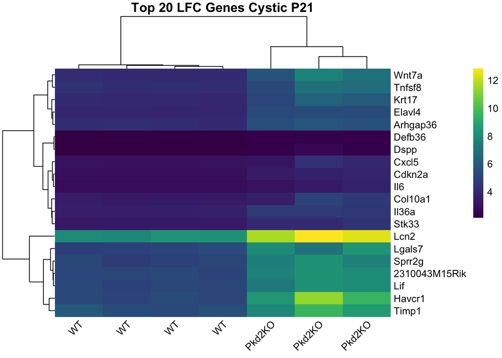

```r
heatmap_21 <- pheatmap::pheatmap(conv_cts_56[rownames(top20lfc_56), ], cluster_rows = TRUE, cluster_cols = TRUE, show_rownames = TRUE, color = viridis(n= 10000, alpha = 1, begin = 0, end = 1, option = "viridis"), border_color = "NA", main = "Top 20 LFC Genes Cystic P21", angle_col = 45)
```

```r
write.csv(genes_56, file = here("res/deseq2_outputs", "deseq2_p21_fullannotatedres.csv"))
ggsave(heatmap_21, filename = here("res", "fea", "heatmap_p21_top20.pdf"), height = 7, width = 14)
```

gene signature

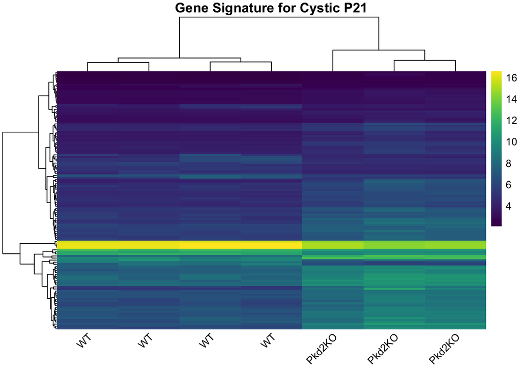

```r
sig_56 <- rbind(hom_56_UP, hom_56_DOWN)
sig_56 <- merge(sig_56, conv_cts_56_all, by.x = "Mouse.gene.stable.ID", by.y = "ensembl_gene_id")
#sig_39 <- tidyr::drop_na(sig_39)
#Filter out repeating data
sig_56 <- dplyr::distinct(sig_56, hgnc_symbol, .keep_all = TRUE)
sig_56_cts <- tibble::column_to_rownames(sig_56, "hgnc_symbol")
#sig_56_cts <- subset(sig_56_cts, select = c("SRR2050895", "SRR2050896", "SRR2050897", "SRR2050898", "SRR2050899", "SRR2050900", "SRR2050901"))
sig_56_cts <- dplyr::select(sig_56_cts, starts_with("SRR"))
colnames(sig_56_cts) <- c("WT", "WT", "WT", "WT", "Pkd2KO", "Pkd2KO", "Pkd2KO")
heatmap_p21 <- pheatmap::pheatmap(sig_56_cts[row.names(sig_56_cts), ], cluster_rows = TRUE, cluster_cols = TRUE, show_rownames = FALSE, fontsize_row = 3, color = viridis(n= 10000, alpha = 1, begin = 0, end = 1, option = "viridis"), border_color = "NA", main = "Gene Signature for Cystic P21", angle_col = 45)
```

```r
write.csv(sig_56, here("res/deseq2_outputs", "signature_annotation_p21.csv"))
ggsave(heatmap_p21, filename = here("res/deseq2_outputs", "heatmap_p21_signature.png"))
```

### DEA p28 cystic GSE134719

#### Read in data

**Filepath to fastq’s and metadata**: /data/project/lasseigne_lab/DATASET_dir/pkdDrugRepurposing/pkd2/GSE134719/SraRunTable.txt  
**Filepath to counts data**: /data/project/lasseigne_lab/Lizzy/PKD_drugrepurposing_220324/GSE134719_nfcore/results/star_salmon/salmon.merged.gene_counts.rds

```r
cts_19 <- readRDS(here("data", "GSE134719_salmonmerged_gene_counts.rds"))
meta_19 <- read.csv(here("data", "GSE134719_metadata.txt"), row.names = 1)
```

#### DDS

```r
cts_19 <- cts_19@assays@data@listData[["counts"]]
dds_19 <- salmon2dds(cts_19, meta_19)
```

```
## [1] "Checking order of count column names to metadata rownames... If false, fix and rerun!"
##  [1] TRUE TRUE TRUE TRUE TRUE TRUE TRUE TRUE TRUE TRUE TRUE TRUE TRUE TRUE TRUE
## [16] TRUE TRUE TRUE TRUE TRUE TRUE TRUE TRUE
```

```r
str(dds_19)
```

[output not shown]

[output cut: 69 more lines]

[output not shown]

#### Run DESeq2

```r
#relevel to make wildtype the reference instead of first alphabetical factor
dds_19$Genotype <- relevel(dds_19$Genotype, ref = "wildtype")
#run DESeq: estimates size factors, estimates dispersion, fits negative binomial GLM's and performs Wald stats
dds_19 <- DESeq(dds_19) #can also look at setting replaceOutliers lower for dealing with outliers
```

```
## -- replacing outliers and refitting for 106 genes
## -- DESeq argument 'minReplicatesForReplace' = 7
## -- original counts are preserved in counts(dds)
```

#### Results

```r
#extract results table with log2 fold changes, p values and adjusted p values for desired coefficients
#res_19 <- results(dds_19, alpha = 0.05, contrast = c("Genotype", "Pdk2KO", "wildtype"))
res_19 <- lfcShrink(dds_19, coef = c("Genotype_Pdk2KO_vs_wildtype"), type="apeglm")
```

```
## using 'apeglm' for LFC shrinkage. If used in published research, please cite:
##     Zhu, A., Ibrahim, J.G., Love, M.I. (2018) Heavy-tailed prior distributions for
##     sequence count data: removing the noise and preserving large differences.
##     Bioinformatics. https://doi.org/10.1093/bioinformatics/bty895
```

DESeq2 results as df and by LFC threshold

```r
dsq2_19 <- as.data.frame(res_19)
```

Save full deseq2 results

```r
write.csv(dsq2_19, file = here("res", "deseq2_outputs", "deseq2_fullres_19.csv"))
saveRDS(dsq2_19, file = here("res", "deseq2_outputs", "deseq2_fullres_19.rds"))
```

#### LFC cutoffs

```r
musdegs_19_UP <- uplfc(dsq2_19, 2.0)
musdegs_19_DOWN <- downlfc(dsq2_19, -2.0)
```

Total genes above threshold before mapping from mouse ensembl to human symbol/entrez

```r
dim(musdegs_19_UP) #1831
```

```
## [1] 1831    6
```

```r
dim(musdegs_19_DOWN) #1631
```

```
## [1] 1631    6
```

Regularized log transformation  
rlog() is better to use for these datasets – better for high count variance by sample (in this case, one sample has over 2x the reads compared to the others in one data set) and for smaller datasets “if you have many samples (e.g. 100s), the rlog function might take too long, and so the vst function will be a faster choice. The rlog and VST have similar properties, but the rlog requires fitting a shrinkage term for each sample and each gene which takes time. See the DESeq2 paper for more discussion on the differences (Love, Huber, and Anders 2014).”

```r
rld_19 <- rlog(dds_19, blind = FALSE)
```

#### Visualizations

PCA

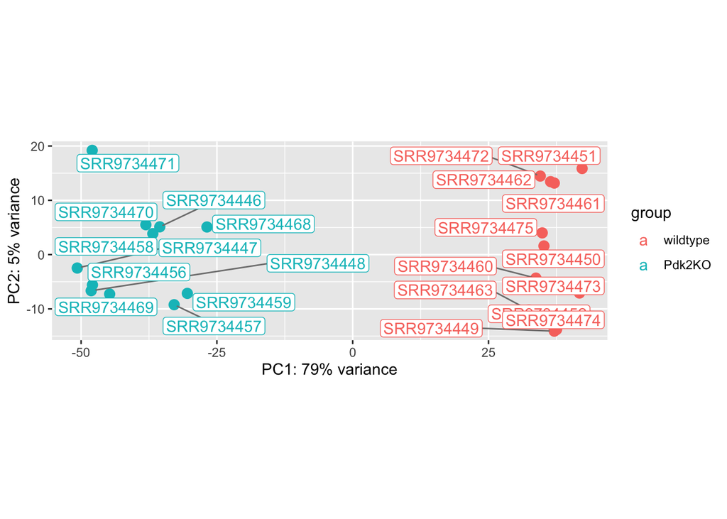

```r
#regularized log transformation
#plotPCA(rld_19, intgroup=c("Genotype"))
#label samples
plotPCA(rld_19, intgroup=c("Genotype")) + geom_label_repel(aes(label = rld_19@colData@rownames), box.padding   = 0.15, label.padding = 0.15, point.padding = 0.3, segment.color = 'grey50')
```

#### Mouse to Human Ortholog Mapping

Map to human entrez and filter by LINCS genes

```r
hom_19_UP <- lincsGenes(musdegs_19_UP, "up")
hom_19_DOWN <-  lincsGenes(musdegs_19_DOWN, "down")
#should be 100 or less
length(unique(hom_19_UP$entrezgene_id)) #97
```

```
## [1] 97
```

```r
length(unique(hom_19_DOWN$entrezgene_id)) #89
```

```
## [1] 89
```

```r
write.csv(musdegs_19_UP, file = here("res", "deseq2_outputs", "deseq2_upgenes_res_19.csv"))
write.csv(musdegs_19_DOWN, file = here("res", "deseq2_outputs", "deseq2_downgenes_res_19.csv"))

write.csv(hom_19_UP, file = here("res", "deseq2_outputs", "p28_signature_UP.csv"))
write.csv(hom_19_DOWN, file = here("res", "deseq2_outputs", "p28_signature_DOWN.csv"))
```

#### Heatmap plotting

converting gene IDs for normalized (rlog) gene counts

```r
#retrieve counts data and ENMUSG #
cts_df_19 <- as.data.frame(assays((rld_19)))
#gene_id into a column
cts_df_19 <- tibble:::rownames_to_column(cts_df_19, var = "ensembl_gene_id")
#Merge gene symbols into counts and gene ID
conv_cts_19_all <- merge(cts_df_19, coding_genes, by = "ensembl_gene_id")
#Filter out repeating data
conv_cts_19_all <- dplyr::distinct(conv_cts_19_all, mgi_symbol, .keep_all = TRUE)
#Convert back to rownames but with gene symbols
conv_cts_19 <- tibble:::column_to_rownames(conv_cts_19_all, "mgi_symbol")
#Remove unnecessary data
conv_cts_19 <- conv_cts_19[,!(colnames(conv_cts_19) %in% c("ensembl_gene_id", "group", "group_name", "entrezgene_id", "description"))]
#Rename the count data to correspond with experimental group or control
colnames(conv_cts_19) <- c("Pkd2KO", "Pkd2KO", "Pkd2KO", "WT", "WT", "WT", "WT", "Pkd2KO", "Pkd2KO", "Pkd2KO", "Pkd2KO", "WT", "WT", "WT", "WT", "Pkd2KO", "Pkkd2KO", "Pkd2KO", "Pkd2KO", "WT", "WT", "WT", "WT")
```

greatest LFC, wrangling

```r
genes_19 <-  tibble:::rownames_to_column(dsq2_19, var = "ensembl_gene_id")
#Merge gene symbols into counts and gene ID
genes_19 <- merge(genes_19, coding_genes, by = "ensembl_gene_id")
#Filter out repeating data
genes_19 <- dplyr::distinct(genes_19, mgi_symbol, .keep_all = TRUE)
#Convert back to rownames but with gene symbols
genes_19 <-  tibble:::column_to_rownames(genes_19, "mgi_symbol")
#top 20
top20lfc_19 <- dplyr::slice_max(genes_19, abs(log2FoldChange), n = 20)
```

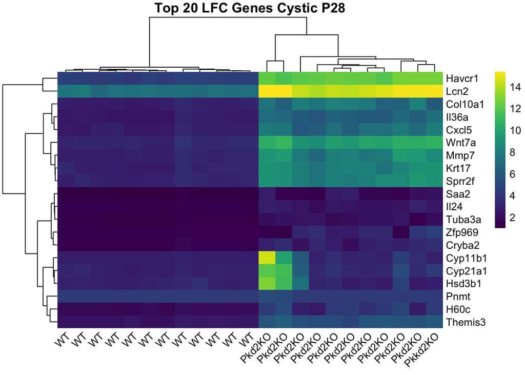

```r
heatmap_p28 <- pheatmap::pheatmap(conv_cts_19[rownames(top20lfc_19), ], cluster_rows = TRUE, cluster_cols = TRUE, show_rownames = TRUE, color = viridis(n= 10000, alpha = 1, begin = 0, end = 1, option = "viridis"), border_color = "NA", main = "Top 20 LFC Genes Cystic P28", angle_col = 45)
```

```r
write.csv(genes_19, file = here("res/deseq2_outputs", "deseq2_p28_fullannotatedres.csv"))
ggsave(heatmap_p28, filename = here("res", "fea", "heatmap_p28.pdf"), height = 7, width = 14)
```

gene signature

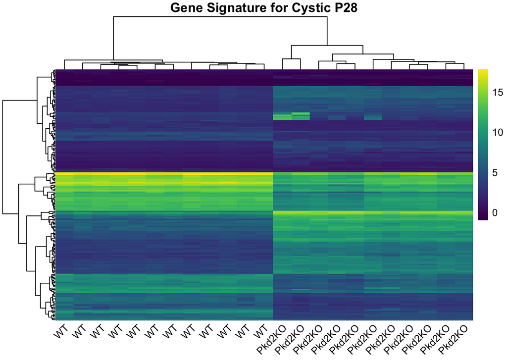

```r
sig_19 <- rbind(hom_19_UP, hom_19_DOWN)
sig_19 <- merge(sig_19, conv_cts_19_all, by.x = "Mouse.gene.stable.ID", by.y = "ensembl_gene_id")
#sig_19 <- tidyr::drop_na(sig_19)
#Filter out repeating data
sig_19 <- dplyr::distinct(sig_19, hgnc_symbol, .keep_all = TRUE)
sig_19_cts <- tibble::column_to_rownames(sig_19, "hgnc_symbol")
#srr_19 <- str_subset(colnames(sig_19_cts), "SRR")
#sig_19_cts <- subset(sig_19_cts, select = c(srr_19))
sig_19_cts <- dplyr::select(sig_19_cts, starts_with("SRR"))
colnames(sig_19_cts) <- c("Pkd2KO", "Pkd2KO", "Pkd2KO", "WT", "WT", "WT", "WT", "Pkd2KO", "Pkd2KO", "Pkd2KO", "Pkd2KO", "WT", "WT", "WT", "WT", "Pkd2KO", "Pkd2KO", "Pkd2KO", "Pkd2KO", "WT", "WT", "WT", "WT")
heatmap_p28 <- pheatmap::pheatmap(sig_19_cts[row.names(sig_19_cts), ], cluster_rows = TRUE, cluster_cols = TRUE, show_rownames = FALSE, fontsize_row = 2.5, color = viridis(n= 10000, alpha = 1, begin = 0, end = 1, option = "viridis"), border_color = "NA", main = "Gene Signature for Cystic P28", angle_col = 45)
```

```r
write.csv(sig_19, here("res/deseq2_outputs", "signature_annotation_p28.csv"))
ggsave(heatmap_p28, filename = here("res/deseq2_outputs", "heatmap_p28_signature.png"))
R.Version()
```

```
## $platform
## [1] "x86_64-apple-darwin17.0"
##
## $arch
## [1] "x86_64"
##
## $os
## [1] "darwin17.0"
##
## $system
## [1] "x86_64, darwin17.0"
##
## $status
## [1] ""
##
## $major
## [1] "4"
##
## $minor
## [1] "2.0"
##
## $year
## [1] "2022"
##
## $month
## [1] "04"
##
## $day
## [1] "22"
##
## $`svn rev`
## [1] "82229"
##
## $language
## [1] "R"
##
## $version.string
## [1] "R version 4.2.0 (2022-04-22)"
##
## $nickname
## [1] "Vigorous Calisthenics"
```

```r
installed.packages()[names(sessionInfo()$otherPkgs), "Version"]
```

```
##  signatureSearchData      EnhancedVolcano                 here
##             "1.10.0"             "1.14.0"              "1.0.1"
##              viridis          viridisLite              biomaRt
##              "0.6.2"              "0.4.1"             "2.52.0"
##                rhdf5        ExperimentHub        AnnotationHub
##             "2.40.0"              "2.4.0"              "3.4.0"
##        BiocFileCache               dbplyr      signatureSearch
##              "2.4.0"              "2.2.1"             "1.10.0"
##                 Rcpp              ggrepel              ggplot2
##              "1.0.9"              "0.9.2"              "3.4.0"
##                dplyr             pheatmap               apeglm
##             "1.0.10"             "1.0.12"             "1.18.0"
##              stringr               DESeq2 SummarizedExperiment
##              "1.4.1"             "1.36.0"             "1.26.1"
##              Biobase       MatrixGenerics          matrixStats
##             "2.56.0"              "1.8.1"             "0.62.0"
##        GenomicRanges         GenomeInfoDb              IRanges
##             "1.48.0"             "1.32.4"             "2.30.1"
##            S4Vectors         BiocGenerics
##             "0.34.0"             "0.42.0"
```